# lab6

Author

Haoyu

## Setup packages

```r
library(tidytext)
```

## Read in Medical Transcriptions

```r
library(readr)
library(dplyr)
mt_samples <- read_csv("https://raw.githubusercontent.com/USCbiostats/data-science-data/master/00_mtsamples/mtsamples.csv")
mt_samples <- mt_samples %>%
  select(description, medical_specialty, transcription)
head(mt_samples)
```

```
# A tibble: 6 × 3
  description                                    medical_specialty transcription
  <chr>                                          <chr>             <chr>
1 A 23-year-old white female presents with comp… Allergy / Immuno… "SUBJECTIVE:…
2 Consult for laparoscopic gastric bypass.       Bariatrics        "PAST MEDICA…
3 Consult for laparoscopic gastric bypass.       Bariatrics        "HISTORY OF …
4 2-D M-Mode. Doppler.                           Cardiovascular /… "2-D M-MODE:…
5 2-D Echocardiogram                             Cardiovascular /… "1.  The lef…
6 Morbid obesity.  Laparoscopic antecolic anteg… Bariatrics        "PREOPERATIV…
```

## Question 1: What specialties do we have?

We can use count() from dplyr to figure out how many different catagories do we have? Are these catagories related? overlapping? evenly distributed?

```r
mt_samples %>%
  count(medical_specialty, sort = TRUE)
```

```
# A tibble: 40 × 2
   medical_specialty                 n
   <chr>                         <int>
 1 Surgery                        1103
 2 Consult - History and Phy.      516
 3 Cardiovascular / Pulmonary      372
 4 Orthopedic                      355
 5 Radiology                       273
 6 General Medicine                259
 7 Gastroenterology                230
 8 Neurology                       223
 9 SOAP / Chart / Progress Notes   166
10 Obstetrics / Gynecology         160
# ℹ 30 more rows
```

We have 40 catagories. These catagories not related and overlapping to each other.But each catagory is unevenly distributed. The most one is “Surgery”,which has 1,000 times, and the second is only 500 times.

## Question 2

Explain what we see from this result. Does it makes sense? What insights (if any) do we get?

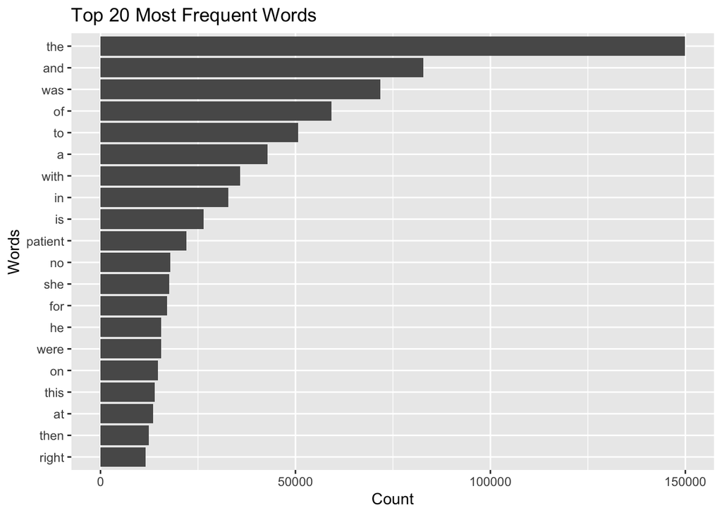

```r
library(ggplot2)
word_counts <- mt_samples %>%
  unnest_tokens(word, transcription) %>%
  count(word, sort = TRUE)
top_20_words <- word_counts %>%
  top_n(20, n) %>%
  ggplot(aes(reorder(word, n), n)) +
  geom_col() +
  coord_flip() +
  labs(title = "Top 20 Most Frequent Words", x = "Words", y = "Count")
top_20_words
```

We see that the top twenty frequency words contain a large number of prepositions and quantifiers, which are not helpful in analyzing the text. Therefore, we need to delete these words.

## Question 3

[figure not shown]

```r
data("stop_words")
clean_word_counts <- mt_samples %>%
  unnest_tokens(word, transcription) %>%
  anti_join(stop_words) %>%
  count(word, sort = TRUE)
top_20_clean_words <- clean_word_counts %>%
  top_n(20, n) %>%
  ggplot(aes(reorder(word, n), n)) +
  geom_col() +
  coord_flip() +
  labs(title = "Top 20 Words After Removing Stopwords And Numbers", x = "Words", y = "Count")
top_20_clean_words
```

We can find that in Top 20 Words, there are no stop words, which is different from the previous result. From the result, the word that appears most often is “patient”, and the word that appears in the top 20 frequencies is “pain” and “blood”, which shows that this text is about medicine.

## Question 4

Repeat question 2, but this time tokenize into bi-grams. how does the result change if you look at tri-grams?

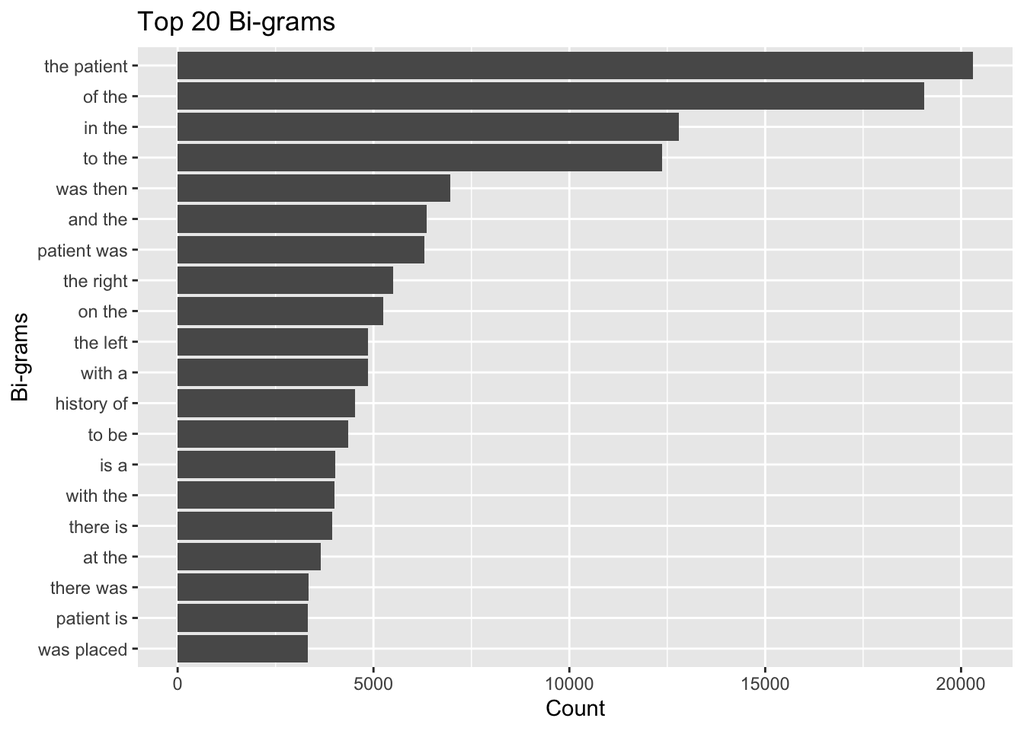

```r
bi_grams <- mt_samples %>%
  unnest_ngrams(bigram, transcription, n = 2) %>%
  count(bigram, sort = TRUE)

tri_grams <- mt_samples %>%
  unnest_ngrams(trigram, transcription, n = 3) %>%
  count(trigram, sort = TRUE)

top_20_bi_grams <- bi_grams %>%
  top_n(20, n) %>%
  ggplot(aes(reorder(bigram, n), n)) +
  geom_col() +
  coord_flip() +
  labs(title = "Top 20 Bi-grams", x = "Bi-grams", y = "Count")
top_20_bi_grams
```

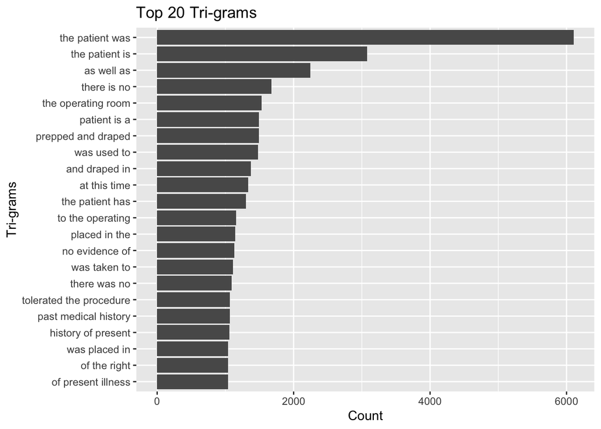

```r
top_20_tri_grams <- tri_grams %>%
  top_n(20, n) %>%
  ggplot(aes(reorder(trigram, n), n)) +
  geom_col() +
  coord_flip() +
  labs(title = "Top 20 Tri-grams", x = "Tri-grams", y = "Count")
top_20_tri_grams
```

These two results are similar, because the word that appears most both include “patient”.

## Question 5

```r
surrounding_words <- mt_samples %>%
  unnest_tokens(word, transcription) %>%
  mutate(next_word = lead(word)) %>%
  filter(word == "patient") %>%
  count(next_word, sort = TRUE)
surrounding_words
```

```
# A tibble: 598 × 2
   next_word     n
   <chr>     <int>
 1 was        6293
 2 is         3332
 3 has        1417
 4 tolerated   994
 5 had         888
 6 will        616
 7 denies      552
 8 and         377
 9 states      363
10 does        334
# ℹ 588 more rows
```

## Question 6

Which words are most used in each of the specialties. you can use group_by() and top_n() from dplyr to have the calculations be done within each specialty. Remember to remove stopwords. How about the most 5 used words?

```r
specialty_word_counts_1 <- mt_samples %>%
  unnest_tokens(word, transcription) %>%
  anti_join(stop_words) %>%
  group_by(medical_specialty) %>%
  count(word, sort = TRUE) %>%
  top_n(1, n)
specialty_word_counts_1
```

```
# A tibble: 41 × 3
# Groups:   medical_specialty [40]
   medical_specialty          word        n
   <chr>                      <chr>   <int>
 1 Surgery                    patient  4855
 2 Consult - History and Phy. patient  3046
 3 Orthopedic                 patient  1711
 4 Cardiovascular / Pulmonary left     1550
 5 General Medicine           patient  1356
 6 Gastroenterology           patient   872
 7 Urology                    patient   776
 8 Radiology                  left      701
 9 Emergency Room Reports     patient   685
10 Discharge Summary          patient   672
# ℹ 31 more rows
```

```r
specialty_word_counts_5 <- mt_samples %>%
  unnest_tokens(word, transcription) %>%
  anti_join(stop_words) %>%
  group_by(medical_specialty) %>%
  count(word, sort = TRUE) %>%
  top_n(5, n)
specialty_word_counts_5
```

```
# A tibble: 209 × 3
# Groups:   medical_specialty [40]
   medical_specialty          word          n
   <chr>                      <chr>     <int>
 1 Surgery                    patient    4855
 2 Surgery                    left       3263
 3 Surgery                    procedure  3243
 4 Consult - History and Phy. patient    3046
 5 Consult - History and Phy. history    2820
 6 Surgery                    0          2094
 7 Surgery                    1          2038
 8 Orthopedic                 patient    1711
 9 Cardiovascular / Pulmonary left       1550
10 Cardiovascular / Pulmonary patient    1516
# ℹ 199 more rows
```

## Question 7

```r
word_counts_specialty <- mt_samples %>%
  unnest_tokens(word, transcription) %>%
  anti_join(stop_words) %>%
  group_by(medical_specialty, word) %>%
  count(word, sort = TRUE)
target_word <- "blood"
word_usage <- word_counts_specialty %>%
  filter(word == target_word)
word_usage
```

```
# A tibble: 39 × 3
# Groups:   medical_specialty, word [39]
   medical_specialty             word      n
   <chr>                         <chr> <int>
 1 Surgery                       blood   734
 2 Consult - History and Phy.    blood   600
 3 General Medicine              blood   407
 4 Cardiovascular / Pulmonary    blood   310
 5 SOAP / Chart / Progress Notes blood   194
 6 Orthopedic                    blood   187
 7 Obstetrics / Gynecology       blood   184
 8 Gastroenterology              blood   145
 9 Emergency Room Reports        blood   132
10 Discharge Summary             blood   115
# ℹ 29 more rows
```

“Blood” appears more frequently in “surgery” than other categories.